# AppliedStatistics_Project

## PART 1

### Ques 1

Question: Please refer the table below to answer below questions: Planned to purchase Product A Actually placed and order for Product A-Yes Actually placed and order for Product A-No Total Yes 400 100 500 No 200 1300 1500 Total 600 1400 2000

1. Refer to the above table and find the joint probability of the people who planned to purchase and actually placed an order.
2. Refer to the above table and find the joint probability of the people who planned to purchase and actually placed an order, given that people planned to purchase.

```python
a1 = 400 / 2000
print("The joint probability of the people who planned to purchase and actually placed an order : ", a1)
```

```
The joint probability of the people who planned to purchase and actually placed an order :  0.2
```

```python
a2 = 400 / 500
print("The joint probability of the people who planned to purchase and actually placed an order, given that people planned to purchase : ", a2)
```

```
The joint probability of the people who planned to purchase and actually placed an order, given that people planned to purchase :  0.8
```

### Ques 2

Question: An electrical manufacturing company conducts quality checks at specified periods on the products it manufactures. Historically, the failure rate for the manufactured item is 5%. Suppose a random sample of 10 manufactured items is selected. Answer the following questions. A. Probability that none of the items are defective? B. Probability that exactly one of the items is defective? C. Probability that two or fewer of the items are defective? D. Probability that three or more of the items are defective ?

```python
import numpy as np
import scipy.stats as stats
```

```python
#Using binomial distribution to solve this problem
p = 0.05
n = 10
k = np.arange(0,10)

a = stats.binom.pmf(k,n,p)
print(a)
```

```
[5.98736939e-01 3.15124705e-01 7.46347985e-02 1.04750594e-02
 9.64808106e-04 6.09352488e-05 2.67259863e-06 8.03789063e-08
 1.58642578e-09 1.85546875e-11]
```

```python
print("Probability that none of the items are defective : ", a[0])
```

```
Probability that none of the items are defective :  0.5987369392383789
```

```python
print("Probability that exactly one of the items is defective : ", a[1])
```

```
Probability that exactly one of the items is defective :  0.31512470486230504
```

```python
a3 = a[0]+a[1]+a[2]
print("Probability that two or fewer of the items are defective :", a3)
```

```
Probability that two or fewer of the items are defective : 0.9884964426207035
```

```python
a4 = 1  - a3
print("Probability that three or more of the items are defective :", a4)
```

```
Probability that three or more of the items are defective : 0.011503557379296536
```

### Ques 3

```python
#Using Poisson distribution to solve this problem
m = 3
k = np.arange(0,10)

b = stats.poisson.pmf(k,m)
print(b)
```

```
[0.04978707 0.14936121 0.22404181 0.22404181 0.16803136 0.10081881
 0.05040941 0.02160403 0.00810151 0.0027005 ]
```

```python
a1 = 1 - b[0]
print("Probability that in a given week he will sell some cars :", a1)
```

```
Probability that in a given week he will sell some cars : 0.950212931632136
```

```python
a2 = b[2]+b[3]+b[4]
print("Probability that in a given week he will sell 2 or more but less than 5 cars : ", a2)
```

```
Probability that in a given week he will sell 2 or more but less than 5 cars :  0.6161149710523164
```

### Ques 4

Question: Accuracy in understanding orders for a speech based bot at a restaurant is important for the Company X which has designed, marketed and launched the product for a contactless delivery due to the COVID-19 pandemic. Recognition accuracy that measures the percentage of orders that are taken correctly is 86.8%. Suppose that you place order with the bot and two friends of yours independently place orders with the same bot. Answer the following questions. A. What is the probability that all three orders will be recognised correctly? B. What is the probability that none of the three orders will be recognised correctly? C. What is the probability that at least two of the three orders will be recognised correctly?

```python
a1 = (0.868 ** 3)
print("Probability that all three orders will be recognised correctly : ",a1)
```

```
Probability that all three orders will be recognised correctly :  0.653972032
```

```python
b = 1-0.868
a2 = (b ** 3)
print("Probability that none of the three orders will be recognised correctly : ",a2)
```

```
Probability that none of the three orders will be recognised correctly :  0.0022999680000000003
```

```python
d = 3*(0.868**2)*(0.132)
a3 = d+a1
print("Probability that atleast two of the three orders will be filled correctly : ", a3)
```

```
Probability that atleast two of the three orders will be filled correctly :  0.952327936
```

### Ques 5

Question: A group of 300 professionals sat for a competitive exam. The results show the information of marks obtained by them have a mean of 60 and a standard deviation of 12. The pattern of marks follows a normal distribution. Answer the following questions. A. What is the percentage of students who score more than 80. B. What is the percentage of students who score less than 50. C. What should be the distinction mark if the highest 10% of students are to be awarded distinction?

```python
m = 60
sd = 12
z1 = (80 - 60) / 12

a = stats.norm.cdf(80,m,sd)
a1 = 1 - a
ans = a1 * 100
print("The percentage of students who score more than 80 : ", ans)
```

```
The percentage of students who score more than 80 :  4.77903522728147
```

```python
m = 60
sd = 12
z2 = (50 - 60) / 12

b = stats.norm.cdf(50,m,sd)
a2 = b*100
print("The percentage of students who score less than 50 : ", a2)
```

```
The percentage of students who score less than 50 :  20.232838096364308
```

```python
b = stats.norm.cdf(90,m,sd)
b
```

```
0.9937903346742238
```

```python
#z-score associated with 90% (0.89973) is 1.28
d = 1.28
#d = (x - m) / sd
#x - m = sd * d
x = m + (sd * d)
print("The distinction mark if the highest 10% of students are to be awarded distinction : ", x)
```

```
The distinction mark if the highest 10% of students are to be awarded distinction :  75.36
```

### Ques 6

Question: Explain 1 real life industry scenario (other than the ones mentioned above) where you can use the concepts learnt in this module of Applied statistics to get a data driven business solution

### ANS

Applied statistics can be used in the music industry to identify the most important factors, person-related and situational related factors which drive people's music selection behavior. Which kind of music gets the most no. of hits, which kind of genre to choose for music composers etc.

## PART 2

Renamed the DS-Part2-Basketball.csv as Basketball.csv

### DATA CLEANING

```python
import pandas as pd
basketball = pd.read_csv("Basketball.csv")
basketball.head(5)
```

|  | Team | Tournament | Score | PlayedGames | WonGames | DrawnGames | LostGames | BasketScored | BasketGiven | TournamentChampion | Runner-up | TeamLaunch | HighestPositionHeld |
| --- | --- | --- | --- | --- | --- | --- | --- | --- | --- | --- | --- | --- | --- |
| 0 | Team 1 | 86 | 4385 | 2762 | 1647 | 552 | 563 | 5947 | 3140 | 33 | 23 | 1929 | 1 |
| 1 | Team 2 | 86 | 4262 | 2762 | 1581 | 573 | 608 | 5900 | 3114 | 25 | 25 | 1929 | 1 |
| 2 | Team 3 | 80 | 3442 | 2614 | 1241 | 598 | 775 | 4534 | 3309 | 10 | 8 | 1929 | 1 |
| 3 | Team 4 | 82 | 3386 | 2664 | 1187 | 616 | 861 | 4398 | 3469 | 6 | 6 | 1931to32 | 1 |
| 4 | Team 5 | 86 | 3368 | 2762 | 1209 | 633 | 920 | 4631 | 3700 | 8 | 7 | 1929 | 1 |

```python
basketball.tail(5)
```

|  | Team | Tournament | Score | PlayedGames | WonGames | DrawnGames | LostGames | BasketScored | BasketGiven | TournamentChampion | Runner-up | TeamLaunch | HighestPositionHeld |
| --- | --- | --- | --- | --- | --- | --- | --- | --- | --- | --- | --- | --- | --- |
| 56 | Team 57 | 1 | 34 | 38 | 8 | 10 | 20 | 38 | 66 | - | - | 2009-10 | 20 |
| 57 | Team 58 | 1 | 22 | 30 | 7 | 8 | 15 | 37 | 57 | - | - | 1956-57 | 16 |
| 58 | Team 59 | 1 | 19 | 30 | 7 | 5 | 18 | 51 | 85 | - | - | 1951~52 | 16 |
| 59 | Team 60 | 1 | 14 | 30 | 5 | 4 | 21 | 34 | 65 | - | - | 1955-56 | 15 |
| 60 | Team 61 | 1 | - | - | - | - | - | - | - | - | - | 2017~18 | 9 |

```python
print("Shape : ",basketball.shape)
print("Size : ",basketball.size)
```

```
Shape :  (61, 13)
Size :  793
```

```python
basketball.info()
```

```
<class 'pandas.core.frame.DataFrame'>
RangeIndex: 61 entries, 0 to 60
Data columns (total 13 columns):
 #   Column               Non-Null Count  Dtype
---  ------               --------------  -----
 0   Team                 61 non-null     object
 1   Tournament           61 non-null     int64
 2   Score                61 non-null     object
 3   PlayedGames          61 non-null     object
 4   WonGames             61 non-null     object
 5   DrawnGames           61 non-null     object
 6   LostGames            61 non-null     object
 7   BasketScored         61 non-null     object
 8   BasketGiven          61 non-null     object
 9   TournamentChampion   61 non-null     object
 10  Runner-up            61 non-null     object
 11  TeamLaunch           61 non-null     object
 12  HighestPositionHeld  61 non-null     int64
dtypes: int64(2), object(11)
memory usage: 6.3+ KB
```

```python
# identifying the rows where score is '-'
basketball[basketball.Score == '-']
```

|  | Team | Tournament | Score | PlayedGames | WonGames | DrawnGames | LostGames | BasketScored | BasketGiven | TournamentChampion | Runner-up | TeamLaunch | HighestPositionHeld |
| --- | --- | --- | --- | --- | --- | --- | --- | --- | --- | --- | --- | --- | --- |
| 60 | Team 61 | 1 | - | - | - | - | - | - | - | - | - | 2017~18 | 9 |

```python
# removing the rows where score is '-'
basketball = basketball[basketball.Score != '-']
```

```python
basketball.tail(5)
```

|  | Team | Tournament | Score | PlayedGames | WonGames | DrawnGames | LostGames | BasketScored | BasketGiven | TournamentChampion | Runner-up | TeamLaunch | HighestPositionHeld |
| --- | --- | --- | --- | --- | --- | --- | --- | --- | --- | --- | --- | --- | --- |
| 55 | Team 56 | 1 | 35 | 38 | 8 | 11 | 19 | 36 | 55 | - | - | 2016_17 | 17 |
| 56 | Team 57 | 1 | 34 | 38 | 8 | 10 | 20 | 38 | 66 | - | - | 2009-10 | 20 |
| 57 | Team 58 | 1 | 22 | 30 | 7 | 8 | 15 | 37 | 57 | - | - | 1956-57 | 16 |
| 58 | Team 59 | 1 | 19 | 30 | 7 | 5 | 18 | 51 | 85 | - | - | 1951~52 | 16 |
| 59 | Team 60 | 1 | 14 | 30 | 5 | 4 | 21 | 34 | 65 | - | - | 1955-56 | 15 |

```python
basketball.info()
```

```
<class 'pandas.core.frame.DataFrame'>
Int64Index: 60 entries, 0 to 59
Data columns (total 13 columns):
 #   Column               Non-Null Count  Dtype
---  ------               --------------  -----
 0   Team                 60 non-null     object
 1   Tournament           60 non-null     int64
 2   Score                60 non-null     object
 3   PlayedGames          60 non-null     object
 4   WonGames             60 non-null     object
 5   DrawnGames           60 non-null     object
 6   LostGames            60 non-null     object
 7   BasketScored         60 non-null     object
 8   BasketGiven          60 non-null     object
 9   TournamentChampion   60 non-null     object
 10  Runner-up            60 non-null     object
 11  TeamLaunch           60 non-null     object
 12  HighestPositionHeld  60 non-null     int64
dtypes: int64(2), object(11)
memory usage: 6.6+ KB
```

```python
#converting the score to numeric data so as to use for analysis
basketball.Score = pd.to_numeric(basketball.Score)
```

```python
basketball.info()
```

```
<class 'pandas.core.frame.DataFrame'>
Int64Index: 60 entries, 0 to 59
Data columns (total 13 columns):
 #   Column               Non-Null Count  Dtype
---  ------               --------------  -----
 0   Team                 60 non-null     object
 1   Tournament           60 non-null     int64
 2   Score                60 non-null     int64
 3   PlayedGames          60 non-null     object
 4   WonGames             60 non-null     object
 5   DrawnGames           60 non-null     object
 6   LostGames            60 non-null     object
 7   BasketScored         60 non-null     object
 8   BasketGiven          60 non-null     object
 9   TournamentChampion   60 non-null     object
 10  Runner-up            60 non-null     object
 11  TeamLaunch           60 non-null     object
 12  HighestPositionHeld  60 non-null     int64
dtypes: int64(3), object(10)
memory usage: 6.6+ KB
```

```python
#replacing all the values where it is '-' to NaN so as to find no of NaNs and fill in data if required
basketball = basketball.replace('-',np.nan)
```

```python
basketball.tail(5)
```

|  | Team | Tournament | Score | PlayedGames | WonGames | DrawnGames | LostGames | BasketScored | BasketGiven | TournamentChampion | Runner-up | TeamLaunch | HighestPositionHeld |
| --- | --- | --- | --- | --- | --- | --- | --- | --- | --- | --- | --- | --- | --- |
| 55 | Team 56 | 1 | 35 | 38 | 8 | 11 | 19 | 36 | 55 | NaN | NaN | 2016_17 | 17 |
| 56 | Team 57 | 1 | 34 | 38 | 8 | 10 | 20 | 38 | 66 | NaN | NaN | 2009-10 | 20 |
| 57 | Team 58 | 1 | 22 | 30 | 7 | 8 | 15 | 37 | 57 | NaN | NaN | 1956-57 | 16 |
| 58 | Team 59 | 1 | 19 | 30 | 7 | 5 | 18 | 51 | 85 | NaN | NaN | 1951~52 | 16 |
| 59 | Team 60 | 1 | 14 | 30 | 5 | 4 | 21 | 34 | 65 | NaN | NaN | 1955-56 | 15 |

```python
basketball.isnull().any()
```

```
Team                   False
Tournament             False
Score                  False
PlayedGames            False
WonGames               False
DrawnGames             False
LostGames              False
BasketScored           False
BasketGiven            False
TournamentChampion      True
Runner-up               True
TeamLaunch             False
HighestPositionHeld    False
dtype: bool
```

```python
basketball['TournamentChampion'].count()
```

```
9
```

```python
basketball['Runner-up'].count()
```

```
13
```

```python
#since we found out that only 9 rows are non null in tournament champion and only 13 rows are non null in runner up.
#substituting rest all as 0 as this can be used to find best team
basketball = basketball.replace(np.nan,0)
```

```python
#as of now no nulls in the dataset
basketball.isnull().any()
```

```
Team                   False
Tournament             False
Score                  False
PlayedGames            False
WonGames               False
DrawnGames             False
LostGames              False
BasketScored           False
BasketGiven            False
TournamentChampion     False
Runner-up              False
TeamLaunch             False
HighestPositionHeld    False
dtype: bool
```

```python
#extracting only the first year (first 4 digits) from the year launch column so as to find the oldest / newest team
basketball['TeamLaunch'] = basketball['TeamLaunch'].str.extract(r'^(\d{4})', expand=False)
basketball.head()
#now our dataset is ready for analysis
```

|  | Team | Tournament | Score | PlayedGames | WonGames | DrawnGames | LostGames | BasketScored | BasketGiven | TournamentChampion | Runner-up | TeamLaunch | HighestPositionHeld |
| --- | --- | --- | --- | --- | --- | --- | --- | --- | --- | --- | --- | --- | --- |
| 0 | Team 1 | 86 | 4385 | 2762 | 1647 | 552 | 563 | 5947 | 3140 | 33 | 23 | 1929 | 1 |
| 1 | Team 2 | 86 | 4262 | 2762 | 1581 | 573 | 608 | 5900 | 3114 | 25 | 25 | 1929 | 1 |
| 2 | Team 3 | 80 | 3442 | 2614 | 1241 | 598 | 775 | 4534 | 3309 | 10 | 8 | 1929 | 1 |
| 3 | Team 4 | 82 | 3386 | 2664 | 1187 | 616 | 861 | 4398 | 3469 | 6 | 6 | 1931 | 1 |
| 4 | Team 5 | 86 | 3368 | 2762 | 1209 | 633 | 920 | 4631 | 3700 | 8 | 7 | 1929 | 1 |

### DATA INTERPRETATION

```python
basketball.Tournament = pd.to_numeric(basketball.Tournament)
basketball.PlayedGames = pd.to_numeric(basketball.PlayedGames)
basketball.WonGames = pd.to_numeric(basketball.WonGames)
basketball.DrawnGames = pd.to_numeric(basketball.DrawnGames)
basketball.LostGames = pd.to_numeric(basketball.LostGames)
basketball.BasketScored = pd.to_numeric(basketball.BasketScored)
basketball.BasketGiven = pd.to_numeric(basketball.BasketGiven)
basketball.TournamentChampion = pd.to_numeric(basketball.TournamentChampion)
#basketball[Runner-up] = pd.to_numeric(basketball[Runner-up])

basketball.describe().transpose()
```

|  | count | mean | std | min | 25% | 50% | 75% | max |
| --- | --- | --- | --- | --- | --- | --- | --- | --- |
| Tournament | 60.0 | 24.383333 | 26.884620 | 1.0 | 4.00 | 12.0 | 39.00 | 86.0 |
| Score | 60.0 | 916.450000 | 1138.342899 | 14.0 | 104.25 | 395.5 | 1360.50 | 4385.0 |
| PlayedGames | 60.0 | 810.100000 | 877.465393 | 30.0 | 115.50 | 424.5 | 1345.50 | 2762.0 |
| WonGames | 60.0 | 309.033333 | 408.481395 | 5.0 | 34.75 | 124.0 | 432.75 | 1647.0 |
| DrawnGames | 60.0 | 192.083333 | 201.985508 | 4.0 | 26.25 | 98.5 | 331.50 | 633.0 |
| LostGames | 60.0 | 308.816667 | 294.508639 | 15.0 | 62.75 | 197.5 | 563.50 | 1070.0 |
| BasketScored | 60.0 | 1159.350000 | 1512.063948 | 34.0 | 154.50 | 444.0 | 1669.75 | 5947.0 |
| BasketGiven | 60.0 | 1159.233333 | 1163.946914 | 55.0 | 236.00 | 632.5 | 2001.25 | 3889.0 |
| TournamentChampion | 60.0 | 1.450000 | 5.515540 | 0.0 | 0.00 | 0.0 | 0.00 | 33.0 |
| HighestPositionHeld | 60.0 | 7.050000 | 5.315232 | 1.0 | 3.00 | 6.0 | 10.00 | 20.0 |

```python
import matplotlib.pyplot as plt
import seaborn as sns
```

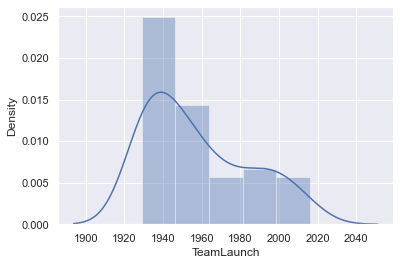

```python
sns.distplot(basketball['TeamLaunch'])
```

```python
df = basketball[['Team', 'TeamLaunch']].groupby('TeamLaunch').count()
df.sort_values(by ='Team', ascending = False).head(5)
#Thus most of teams were started in 1929
```

| TeamLaunch | Team |
| --- | --- |
| 1929 | 10 |
| 1941 | 3 |
| 1935 | 2 |
| 1977 | 2 |
| 1951 | 2 |

```python
#These are the oldest teams and have been the tournament champions
basketball[(basketball.TeamLaunch == '1929') & (basketball.TournamentChampion > 0)]
```

|  | Team | Tournament | Score | PlayedGames | WonGames | DrawnGames | LostGames | BasketScored | BasketGiven | TournamentChampion | Runner-up | TeamLaunch | HighestPositionHeld |
| --- | --- | --- | --- | --- | --- | --- | --- | --- | --- | --- | --- | --- | --- |
| 0 | Team 1 | 86 | 4385 | 2762 | 1647 | 552 | 563 | 5947 | 3140 | 33 | 23 | 1929 | 1 |
| 1 | Team 2 | 86 | 4262 | 2762 | 1581 | 573 | 608 | 5900 | 3114 | 25 | 25 | 1929 | 1 |
| 2 | Team 3 | 80 | 3442 | 2614 | 1241 | 598 | 775 | 4534 | 3309 | 10 | 8 | 1929 | 1 |
| 4 | Team 5 | 86 | 3368 | 2762 | 1209 | 633 | 920 | 4631 | 3700 | 8 | 7 | 1929 | 1 |
| 7 | Team 8 | 70 | 2573 | 2302 | 864 | 577 | 861 | 3228 | 3230 | 2 | 3 | 1929 | 1 |

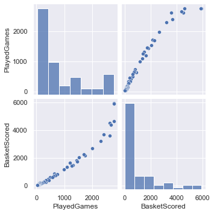

```python
#relationship between PlayedGames and Basketscored
sns.pairplot(basketball[['PlayedGames','BasketScored']])
```

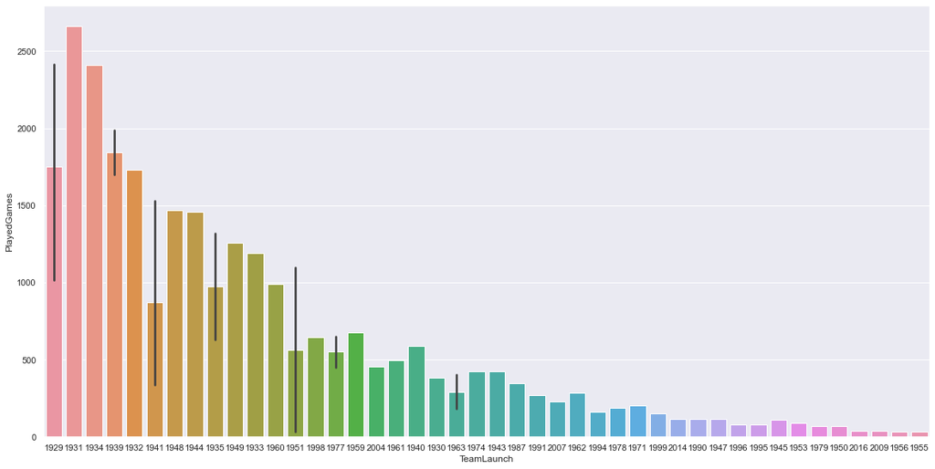

```python
plt.figure(figsize=(20,10))
#yearwise the games which are played
sns.barplot(basketball['TeamLaunch'], basketball['PlayedGames'])
#we can see the max games played by the teams that launched in 1931
```

```python
#correlation between the Played, Won, Lost, Drawn Games
#we see there is high correlation between Played, Won, Lost, Drawn games as Played = Total of Won + Lost + Drawn
cor = basketball[['PlayedGames',
              'WonGames',
              'LostGames',
              'DrawnGames']].corr()
cor
```

|  | PlayedGames | WonGames | LostGames | DrawnGames |
| --- | --- | --- | --- | --- |
| PlayedGames | 1.000000 | 0.967486 | 0.955925 | 0.993972 |
| WonGames | 0.967486 | 1.000000 | 0.851436 | 0.939416 |
| LostGames | 0.955925 | 0.851436 | 1.000000 | 0.972786 |
| DrawnGames | 0.993972 | 0.939416 | 0.972786 | 1.000000 |

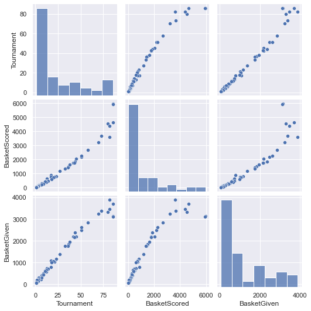

```python
#realtionships between Tournaments played, Baskets scored, baskets given
sns.pairplot(basketball[['Tournament', 'BasketScored', 'BasketGiven']]);
```

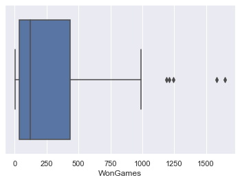

```python
sns.boxplot(basketball['WonGames'])
```

```python
#Here we see these are the top 5 teams which have won more than thousand games
df2 = basketball[basketball.WonGames>1000]
df2.sort_values(by ='WonGames', ascending = False)
```

|  | Team | Tournament | Score | PlayedGames | WonGames | DrawnGames | LostGames | BasketScored | BasketGiven | TournamentChampion | Runner-up | TeamLaunch | HighestPositionHeld |
| --- | --- | --- | --- | --- | --- | --- | --- | --- | --- | --- | --- | --- | --- |
| 0 | Team 1 | 86 | 4385 | 2762 | 1647 | 552 | 563 | 5947 | 3140 | 33 | 23 | 1929 | 1 |
| 1 | Team 2 | 86 | 4262 | 2762 | 1581 | 573 | 608 | 5900 | 3114 | 25 | 25 | 1929 | 1 |
| 2 | Team 3 | 80 | 3442 | 2614 | 1241 | 598 | 775 | 4534 | 3309 | 10 | 8 | 1929 | 1 |
| 4 | Team 5 | 86 | 3368 | 2762 | 1209 | 633 | 920 | 4631 | 3700 | 8 | 7 | 1929 | 1 |
| 3 | Team 4 | 82 | 3386 | 2664 | 1187 | 616 | 861 | 4398 | 3469 | 6 | 6 | 1931 | 1 |

```python
#Here there are top 5 teams who scored more baskets rather than giving more baskets
df3 = basketball[basketball.BasketScored>basketball.BasketGiven]
df3.sort_values(by ='BasketScored', ascending = False).head(5)
```

|  | Team | Tournament | Score | PlayedGames | WonGames | DrawnGames | LostGames | BasketScored | BasketGiven | TournamentChampion | Runner-up | TeamLaunch | HighestPositionHeld |
| --- | --- | --- | --- | --- | --- | --- | --- | --- | --- | --- | --- | --- | --- |
| 0 | Team 1 | 86 | 4385 | 2762 | 1647 | 552 | 563 | 5947 | 3140 | 33 | 23 | 1929 | 1 |
| 1 | Team 2 | 86 | 4262 | 2762 | 1581 | 573 | 608 | 5900 | 3114 | 25 | 25 | 1929 | 1 |
| 4 | Team 5 | 86 | 3368 | 2762 | 1209 | 633 | 920 | 4631 | 3700 | 8 | 7 | 1929 | 1 |
| 2 | Team 3 | 80 | 3442 | 2614 | 1241 | 598 | 775 | 4534 | 3309 | 10 | 8 | 1929 | 1 |
| 3 | Team 4 | 82 | 3386 | 2664 | 1187 | 616 | 861 | 4398 | 3469 | 6 | 6 | 1931 | 1 |

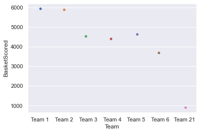

```python
sns.stripplot(df3['Team'],df3['BasketScored'], jitter=True);
```

```python
#The team with highest score
basketball[basketball.Score == basketball.Score.max()]
```

|  | Team | Tournament | Score | PlayedGames | WonGames | DrawnGames | LostGames | BasketScored | BasketGiven | TournamentChampion | Runner-up | TeamLaunch | HighestPositionHeld |
| --- | --- | --- | --- | --- | --- | --- | --- | --- | --- | --- | --- | --- | --- |
| 0 | Team 1 | 86 | 4385 | 2762 | 1647 | 552 | 563 | 5947 | 3140 | 33 | 23 | 1929 | 1 |

```python
#The team with lowest score
basketball[basketball.Score == basketball.Score.min()]
```

|  | Team | Tournament | Score | PlayedGames | WonGames | DrawnGames | LostGames | BasketScored | BasketGiven | TournamentChampion | Runner-up | TeamLaunch | HighestPositionHeld |
| --- | --- | --- | --- | --- | --- | --- | --- | --- | --- | --- | --- | --- | --- |
| 59 | Team 60 | 1 | 14 | 30 | 5 | 4 | 21 | 34 | 65 | 0 | 0 | 1955 | 15 |

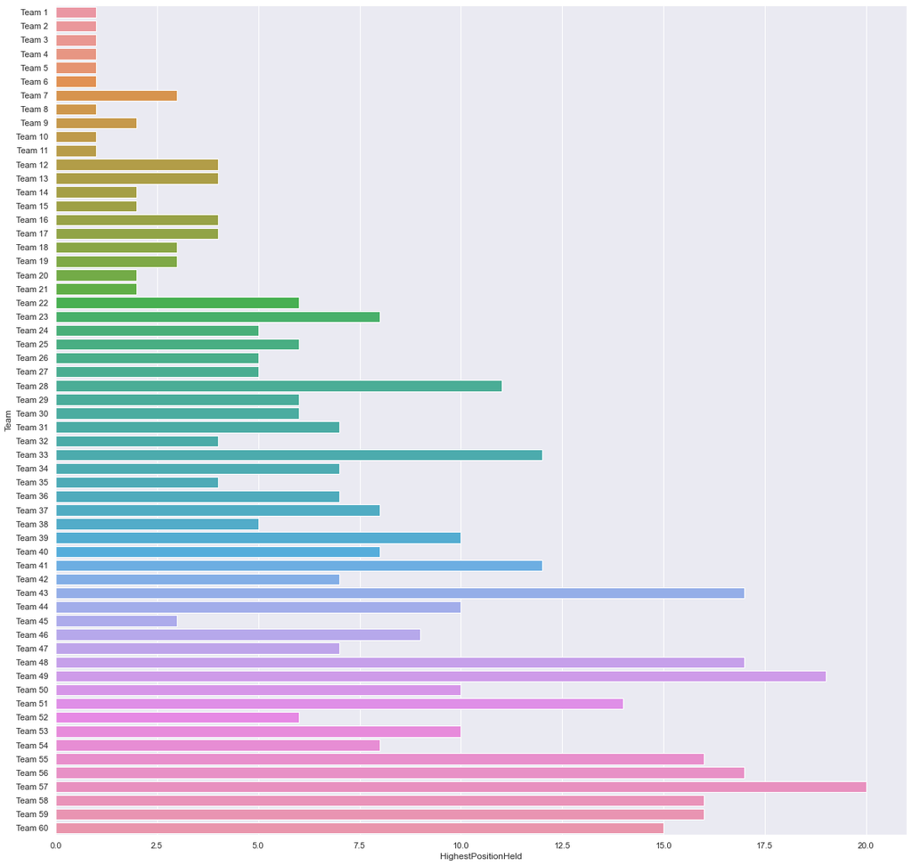

```python
plt.figure(figsize=(20,20))
sns.barplot(basketball['HighestPositionHeld'], basketball['Team'])
```

### IMPROVEMENTS AND SUGGESTIONS

1. Since the TotalGames = WinGames + LostGames + DrawnGames, 3 columns are sufficient as the 4th can be calculated with the rest of the three.
2. The TournamentChampion column is not populated for many Teams, which is an important column.
3. More categorical fields should be used so that more plots can be used to visualise and understand the data.

## PART 3

Renamed the DS-Part3-CompanyX_EU.csv as CompanyX_EU.csv

```python
company = pd.read_csv("CompanyX_EU.csv")
company
```

|  | Startup | Product | Funding | Event | Result | OperatingState |
| --- | --- | --- | --- | --- | --- | --- |
| 0 | 2600Hz | 2600hz.com | NaN | Disrupt SF 2013 | Contestant | Operating |
| 1 | 3DLT | 3dlt.com | $630K | Disrupt NYC 2013 | Contestant | Closed |
| 2 | 3DPrinterOS | 3dprinteros.com | NaN | Disrupt SF 2016 | Contestant | Operating |
| 3 | 3Dprintler | 3dprintler.com | $1M | Disrupt NY 2016 | Audience choice | Operating |
| 4 | 42 Technologies | 42technologies.com | NaN | Disrupt NYC 2013 | Contestant | Operating |
| ... | ... | ... | ... | ... | ... | ... |
| 657 | Zivity | zivity.com | $8M | TC40 2007 | Contestant | Operating |
| 658 | Zmorph | zmorph3d.com | $1M | - | Audience choice | Operating |
| 659 | Zocdoc | zocdoc.com | $223M | TC40 2007 | Contestant | Operating |
| 660 | Zula | zulaapp.com | $3.4M | Disrupt SF 2013 | Audience choice | Operating |
| 661 | Zumper | zumper.com | $31.5M | Disrupt SF 2012 | Finalist | Operating |

662 rows × 6 columns

## Data exploration, Data preprocessing & visualisation:

```python
company.info()
```

```
<class 'pandas.core.frame.DataFrame'>
RangeIndex: 662 entries, 0 to 661
Data columns (total 6 columns):
 #   Column          Non-Null Count  Dtype
---  ------          --------------  -----
 0   Startup         662 non-null    object
 1   Product         656 non-null    object
 2   Funding         448 non-null    object
 3   Event           662 non-null    object
 4   Result          662 non-null    object
 5   OperatingState  662 non-null    object
dtypes: object(6)
memory usage: 31.2+ KB
```

```python
company.isnull().any()
```

```
Startup           False
Product            True
Funding            True
Event             False
Result            False
OperatingState    False
dtype: bool
```

```python
#Product and Funding has null values
company.isnull().sum()
```

```
Startup             0
Product             6
Funding           214
Event               0
Result              0
OperatingState      0
dtype: int64
```

```python
#drop the null value rows
company_new = company.dropna()
company_new
```

|  | Startup | Product | Funding | Event | Result | OperatingState |
| --- | --- | --- | --- | --- | --- | --- |
| 1 | 3DLT | 3dlt.com | $630K | Disrupt NYC 2013 | Contestant | Closed |
| 3 | 3Dprintler | 3dprintler.com | $1M | Disrupt NY 2016 | Audience choice | Operating |
| 5 | 5to1 | 5to1.com | $19.3M | TC50 2009 | Contestant | Acquired |
| 6 | 8 Securities | 8securities.com | $29M | Disrupt Beijing 2011 | Finalist | Operating |
| 10 | AdhereTech | adheretech.com | $1.8M | Hardware Battlefield 2014 | Contestant | Operating |
| ... | ... | ... | ... | ... | ... | ... |
| 657 | Zivity | zivity.com | $8M | TC40 2007 | Contestant | Operating |
| 658 | Zmorph | zmorph3d.com | $1M | - | Audience choice | Operating |
| 659 | Zocdoc | zocdoc.com | $223M | TC40 2007 | Contestant | Operating |
| 660 | Zula | zulaapp.com | $3.4M | Disrupt SF 2013 | Audience choice | Operating |
| 661 | Zumper | zumper.com | $31.5M | Disrupt SF 2012 | Finalist | Operating |

446 rows × 6 columns

```python
#convert the funding column to numbers
df = company_new['Funding'].apply(lambda x : x.replace('$',''))
df
```

```
1       630K
3         1M
5      19.3M
6        29M
10      1.8M
       ...
657       8M
658       1M
659     223M
660     3.4M
661    31.5M
Name: Funding, Length: 446, dtype: object
```

```python
def text_to_num(text, bad_data_val = 0):
    d = {
        'K': 1,
        'M': 1000,
        'B': 1000000
    }
    if not isinstance(text, str):
        # Non-strings are bad are missing data in poster's submission
        return bad_data_val

    elif text[-1] in d:
        # separate out the K, M, or B
        num, magnitude = text[:-1], text[-1]
        return int(float(num) * d[magnitude])
    else:
        return float(text)
```

```python
default_val = 0
company_new['Funding'] = df.apply(lambda x : text_to_num(x, bad_data_val = 0))
#considered 1K,1000K=1M etc.
company_new.head(10)
```

|  | Startup | Product | Funding | Event | Result | OperatingState |
| --- | --- | --- | --- | --- | --- | --- |
| 1 | 3DLT | 3dlt.com | 630 | Disrupt NYC 2013 | Contestant | Closed |
| 3 | 3Dprintler | 3dprintler.com | 1000 | Disrupt NY 2016 | Audience choice | Operating |
| 5 | 5to1 | 5to1.com | 19300 | TC50 2009 | Contestant | Acquired |
| 6 | 8 Securities | 8securities.com | 29000 | Disrupt Beijing 2011 | Finalist | Operating |
| 10 | AdhereTech | adheretech.com | 1800 | Hardware Battlefield 2014 | Contestant | Operating |
| 11 | AdRocket | adrocket.com | 1000 | TC50 2008 | Contestant | Closed |
| 13 | Agrilyst | agrilyst.com | 1000 | Disrupt SF 2015 | Winner | Operating |
| 14 | Aiden | aiden.ai | 750 | Disrupt London 2016 | Contestant | Operating |
| 15 | AirBoxLab | foobot.io | 17 | Hardware Battlefield 2014 | Contestant | Operating |
| 16 | Aircall | aircall.io | 11600 | Disrupt SF 2015 | Contestant | Operating |

```python
company_new.info()
```

```
<class 'pandas.core.frame.DataFrame'>
Int64Index: 446 entries, 1 to 661
Data columns (total 6 columns):
 #   Column          Non-Null Count  Dtype
---  ------          --------------  -----
 0   Startup         446 non-null    object
 1   Product         446 non-null    object
 2   Funding         446 non-null    int64
 3   Event           446 non-null    object
 4   Result          446 non-null    object
 5   OperatingState  446 non-null    object
dtypes: int64(1), object(5)
memory usage: 24.4+ KB
```

```python
company_new.describe().transpose()
```

|  | count | mean | std | min | 25% | 50% | 75% | max |
| --- | --- | --- | --- | --- | --- | --- | --- | --- |
| Funding | 446.0 | 17241.461883 | 90483.713443 | 5.0 | 745.25 | 2200.0 | 9475.0 | 1700000.0 |

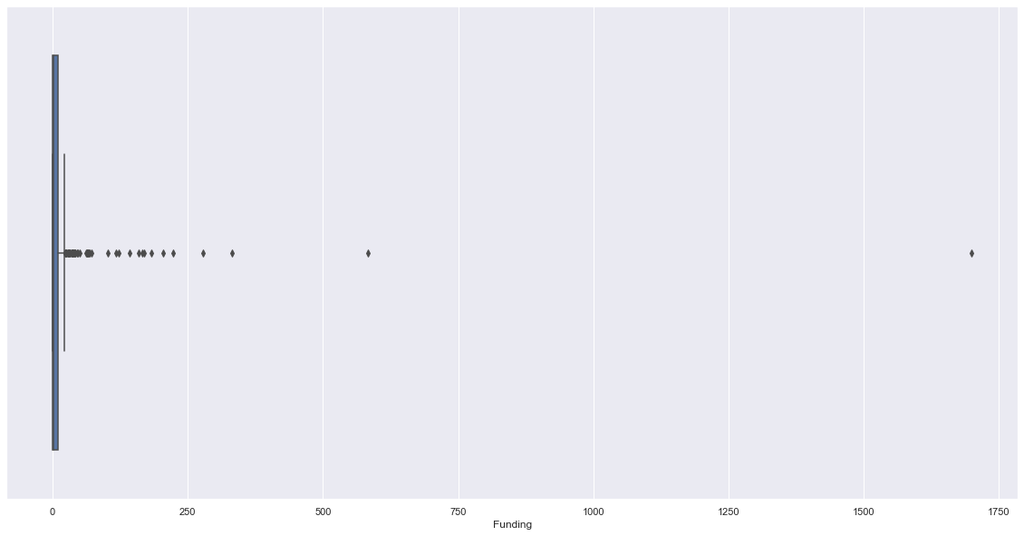

```python
plt.figure(figsize=(20,10))
sns.boxplot(x=company_new['Funding']/1000)
```

```python
#removing outliers greater than upper fence
Q1 = company_new['Funding'].quantile(0.25)
Q3 = company_new['Funding'].quantile(0.75)
IQR = Q3 - Q1    #IQR is interquartile range.

filter = (company_new['Funding'] <= Q3 + 1.5 *IQR)
#filter
company_new = company_new.loc[filter]
company_new
```

|  | Startup | Product | Funding | Event | Result | OperatingState |
| --- | --- | --- | --- | --- | --- | --- |
| 1 | 3DLT | 3dlt.com | 630 | Disrupt NYC 2013 | Contestant | Closed |
| 3 | 3Dprintler | 3dprintler.com | 1000 | Disrupt NY 2016 | Audience choice | Operating |
| 5 | 5to1 | 5to1.com | 19300 | TC50 2009 | Contestant | Acquired |
| 10 | AdhereTech | adheretech.com | 1800 | Hardware Battlefield 2014 | Contestant | Operating |
| 11 | AdRocket | adrocket.com | 1000 | TC50 2008 | Contestant | Closed |
| ... | ... | ... | ... | ... | ... | ... |
| 645 | Yap | yapme.com | 10000 | TC40 2007 | Contestant | Closed |
| 646 | YayPay Inc | yaypay.com | 900 | Disrupt London 2015 | Contestant | Operating |
| 657 | Zivity | zivity.com | 8000 | TC40 2007 | Contestant | Operating |
| 658 | Zmorph | zmorph3d.com | 1000 | - | Audience choice | Operating |
| 660 | Zula | zulaapp.com | 3400 | Disrupt SF 2013 | Audience choice | Operating |

386 rows × 6 columns

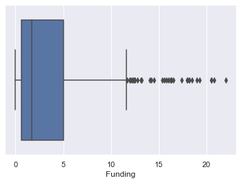

```python
#boxplot after removing the outliers
sns.boxplot(x=company_new['Funding']/1000)
```

```python
#frequency of OperatingState feature classes
company_new['OperatingState'].value_counts()
```

```
Operating    275
Closed        56
Acquired      55
Name: OperatingState, dtype: int64
```

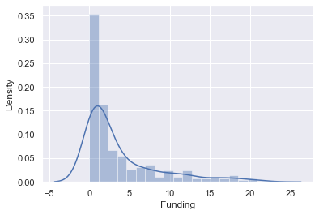

```python
#dist plot for funding in million
sns.distplot(company_new['Funding']/1000);
```

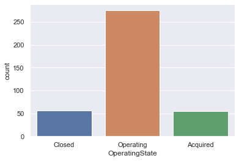

```python
#no. of companies still operating, closed or acquired
sns.countplot(company_new['OperatingState'])
```

## Statistical analysis:

• Is there any significant difference between Funds raised by companies that are still operating vs companies that closed down? Write the null hypothesis and alternative hypothesis. Test for significance and conclusion

#### Ho: There is no significant difference between Funds raised by companies that are still operating vs companies that closed down.

#### Ha: There is a significant difference between Funds raised by companies that are still operating vs companies that closed down.

```python
df_test = company_new[['Funding','OperatingState']]
df_test
```

|  | Funding | OperatingState |
| --- | --- | --- |
| 1 | 630 | Closed |
| 3 | 1000 | Operating |
| 5 | 19300 | Acquired |
| 10 | 1800 | Operating |
| 11 | 1000 | Closed |
| ... | ... | ... |
| 645 | 10000 | Closed |
| 646 | 900 | Operating |
| 657 | 8000 | Operating |
| 658 | 1000 | Operating |
| 660 | 3400 | Operating |

386 rows × 2 columns

```python
df_test1 = df_test[df_test.OperatingState == 'Closed']
df_test1.head(10)
```

|  | Funding | OperatingState |
| --- | --- | --- |
| 1 | 630 | Closed |
| 11 | 1000 | Closed |
| 17 | 929 | Closed |
| 20 | 1900 | Closed |
| 34 | 600 | Closed |
| 48 | 190 | Closed |
| 62 | 20800 | Closed |
| 79 | 8100 | Closed |
| 82 | 325 | Closed |
| 97 | 5500 | Closed |

```python
df_test2 = df_test[df_test.OperatingState == 'Operating']
df_test2.head(10)
```

|  | Funding | OperatingState |
| --- | --- | --- |
| 3 | 1000 | Operating |
| 10 | 1800 | Operating |
| 13 | 1000 | Operating |
| 14 | 750 | Operating |
| 15 | 17 | Operating |
| 16 | 11600 | Operating |
| 18 | 12200 | Operating |
| 22 | 4000 | Operating |
| 32 | 746 | Operating |
| 35 | 7100 | Operating |

```python
df_test1.Funding.describe()
```

```
count       56.000000
mean      2682.410714
std       4060.200419
min         93.000000
25%        443.750000
50%        927.000000
75%       3125.000000
max      20800.000000
Name: Funding, dtype: float64
```

```python
df_test2_head = df_test2.head(56)
df_test2_head.Funding.describe()
```

```
count       56.000000
mean      3551.571429
std       4086.256846
min         17.000000
25%        630.250000
50%       2000.000000
75%       5375.000000
max      20500.000000
Name: Funding, dtype: float64
```

```python
import scipy.stats as st
two_sample = st.ttest_rel(df_test1.Funding, df_test2_head.Funding)
print("\n The t-statistic is %.3f and the p-value is %.3f." % two_sample)
```

```
 The t-statistic is -1.200 and the p-value is 0.235.
```

```python
df_test2_tail = df_test2.tail(56)
df_test2_tail.Funding.describe()
```

```
count       56.000000
mean      2838.392857
std       3586.415332
min         26.000000
25%        600.000000
50%       1750.000000
75%       3100.000000
max      16000.000000
Name: Funding, dtype: float64
```

```python
two_sample = st.ttest_rel(df_test1.Funding, df_test2_tail.Funding)
print("\n The t-statistic is %.3f and the p-value is %.3f." % two_sample)
```

```
 The t-statistic is -0.199 and the p-value is 0.843.
```

In both the cases, t-stat is negative and p-value is quite large, hence we fail to reject the null hypothesis.

Thus, there is no significant difference between Funds raised by companies that are still operating vs companies that closed down

• Make a copy of the original data frame.

```python
#copy of dataset
company_new2 = company_new.copy()
company_new2
```

|  | Startup | Product | Funding | Event | Result | OperatingState |
| --- | --- | --- | --- | --- | --- | --- |
| 1 | 3DLT | 3dlt.com | 630 | Disrupt NYC 2013 | Contestant | Closed |
| 3 | 3Dprintler | 3dprintler.com | 1000 | Disrupt NY 2016 | Audience choice | Operating |
| 5 | 5to1 | 5to1.com | 19300 | TC50 2009 | Contestant | Acquired |
| 10 | AdhereTech | adheretech.com | 1800 | Hardware Battlefield 2014 | Contestant | Operating |
| 11 | AdRocket | adrocket.com | 1000 | TC50 2008 | Contestant | Closed |
| ... | ... | ... | ... | ... | ... | ... |
| 645 | Yap | yapme.com | 10000 | TC40 2007 | Contestant | Closed |
| 646 | YayPay Inc | yaypay.com | 900 | Disrupt London 2015 | Contestant | Operating |
| 657 | Zivity | zivity.com | 8000 | TC40 2007 | Contestant | Operating |
| 658 | Zmorph | zmorph3d.com | 1000 | - | Audience choice | Operating |
| 660 | Zula | zulaapp.com | 3400 | Disrupt SF 2013 | Audience choice | Operating |

386 rows × 6 columns

• Check frequency distribution of Result variable.

```python
company_new2['Result'].value_counts()
```

```
Contestant         282
Finalist            52
Audience choice     20
Winner              17
Runner up           15
Name: Result, dtype: int64
```

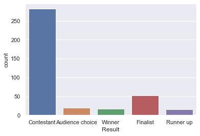

```python
sns.countplot(company_new2['Result'])
```

• Calculate percentage of winners that are still operating and percentage of contestants that are still operating

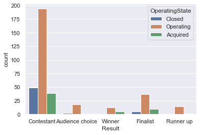

```python
sns.countplot(company_new2['Result'],hue=company_new2['OperatingState']);
```

```python
company_new2.groupby(['Result', 'OperatingState']).size()
```

```
Result           OperatingState
Audience choice  Closed              2
                 Operating          18
Contestant       Acquired           39
                 Closed             49
                 Operating         194
Finalist         Acquired           10
                 Closed              5
                 Operating          37
Runner up        Acquired            1
                 Operating          14
Winner           Acquired            5
                 Operating          12
dtype: int64
```

```python
#So percentage of contestants which are still operating
per_cont = 194/282
print('The Percentage of contestants which are still operating : ',per_cont*100)
```

```
The Percentage of contestants which are still operating :  68.79432624113475
```

```python
#So percentage of winners which are still operating
per_win = 12/17
print('The Percentage of winners which are still operating : ',per_win*100)
```

```
The Percentage of winners which are still operating :  70.58823529411765
```

• Write your hypothesis comparing the proportion of companies that are operating between winners and contestants: Write the null hypothesis and alternative hypothesis. Test for significance and conclusion

#### Ho: The proportions of operating in the winners and the contestestants state is equal

#### Ha: The proportions are different

Using the z-test

```python
from statsmodels.stats.proportion import proportions_ztest

stat, pval = proportions_ztest([12, 194] , [17, 282])

if pval < 0.05:
    print(f'With a p-value of {round(pval,4)} the difference is significant. aka |We reject the null|')
else:
    print(f'With a p-value of {round(pval,4)} the difference is not significant. aka |We fail to reject the null|')
```

```
With a p-value of 0.8767 the difference is not significant. aka |We fail to reject the null|
```

• Check distribution of the Event variable.

```python
company_new2['Event'].value_counts()
```

```
TC50 2008                    25
TC40 2007                    22
Disrupt NY 2015              21
Disrupt SF 2014              19
Disrupt NYC 2012             19
Disrupt NYC 2013             19
Disrupt SF 2011              19
Disrupt SF 2013              19
TC50 2009                    19
Disrupt SF 2015              19
Disrupt SF 2016              17
Disrupt NY 2016              16
Disrupt NYC 2014             15
Disrupt NYC 2011             15
Disrupt SF 2012              15
Disrupt SF 2010              13
Hardware Battlefield 2016    12
Hardware Battlefield 2014    12
Disrupt London 2015          11
Disrupt NYC 2010             10
Disrupt EU 2014              10
Hardware Battlefield 2015    10
Disrupt London 2016          10
Disrupt EU 2013               9
-                             6
Disrupt Beijing 2011          4
Name: Event, dtype: int64
```

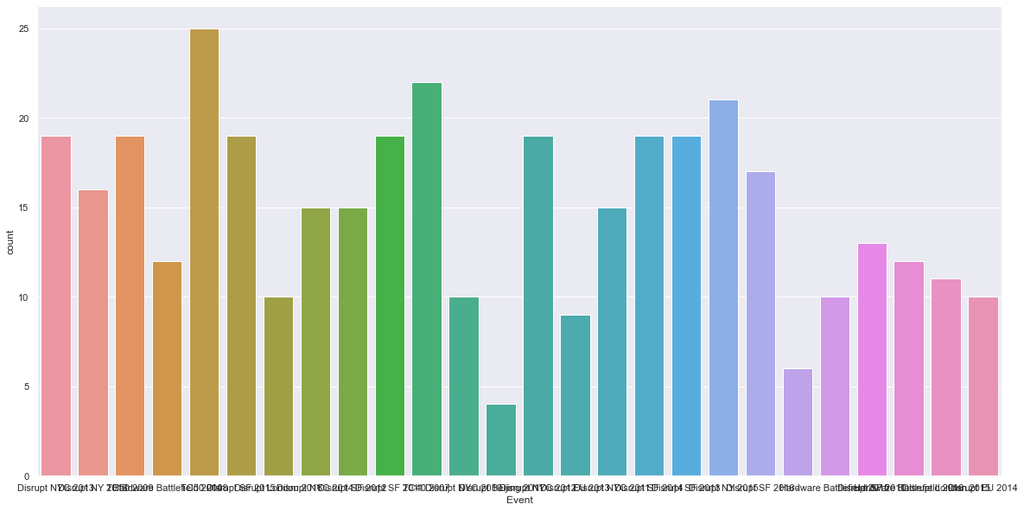

```python
plt.figure(figsize=(20,10))
sns.countplot(company_new2['Event'])
```

• Select only the Event that has disrupt keyword from 2013 onwards.

```python
df_new = company_new2[company_new2.Event.str.startswith('Disrupt')]
df_new
```

|  | Startup | Product | Funding | Event | Result | OperatingState |
| --- | --- | --- | --- | --- | --- | --- |
| 1 | 3DLT | 3dlt.com | 630 | Disrupt NYC 2013 | Contestant | Closed |
| 3 | 3Dprintler | 3dprintler.com | 1000 | Disrupt NY 2016 | Audience choice | Operating |
| 13 | Agrilyst | agrilyst.com | 1000 | Disrupt SF 2015 | Winner | Operating |
| 14 | Aiden | aiden.ai | 750 | Disrupt London 2016 | Contestant | Operating |
| 16 | Aircall | aircall.io | 11600 | Disrupt SF 2015 | Contestant | Operating |
| ... | ... | ... | ... | ... | ... | ... |
| 635 | Welltwigs | welltwigs.com | 50 | Disrupt NY 2015 | Contestant | Operating |
| 641 | Workspot | workspot.com | 15800 | Disrupt NYC 2013 | Contestant | Operating |
| 642 | Xendo | xendo.com | 28 | Disrupt SF 2014 | Contestant | Acquired |
| 646 | YayPay Inc | yaypay.com | 900 | Disrupt London 2015 | Contestant | Operating |
| 660 | Zula | zulaapp.com | 3400 | Disrupt SF 2013 | Audience choice | Operating |

280 rows × 6 columns

```python
df_new[['Keyword', 'Place', 'Year']] = df_new.Event.str.split(" ", expand=True)
df_new.Year = pd.to_numeric(df_new.Year)
df_new[df_new.Year>=2013]
```

|  | Startup | Product | Funding | Event | Result | OperatingState | Keyword | Place | Year |
| --- | --- | --- | --- | --- | --- | --- | --- | --- | --- |
| 1 | 3DLT | 3dlt.com | 630 | Disrupt NYC 2013 | Contestant | Closed | Disrupt | NYC | 2013 |
| 3 | 3Dprintler | 3dprintler.com | 1000 | Disrupt NY 2016 | Audience choice | Operating | Disrupt | NY | 2016 |
| 13 | Agrilyst | agrilyst.com | 1000 | Disrupt SF 2015 | Winner | Operating | Disrupt | SF | 2015 |
| 14 | Aiden | aiden.ai | 750 | Disrupt London 2016 | Contestant | Operating | Disrupt | London | 2016 |
| 16 | Aircall | aircall.io | 11600 | Disrupt SF 2015 | Contestant | Operating | Disrupt | SF | 2015 |
| ... | ... | ... | ... | ... | ... | ... | ... | ... | ... |
| 635 | Welltwigs | welltwigs.com | 50 | Disrupt NY 2015 | Contestant | Operating | Disrupt | NY | 2015 |
| 641 | Workspot | workspot.com | 15800 | Disrupt NYC 2013 | Contestant | Operating | Disrupt | NYC | 2013 |
| 642 | Xendo | xendo.com | 28 | Disrupt SF 2014 | Contestant | Acquired | Disrupt | SF | 2014 |
| 646 | YayPay Inc | yaypay.com | 900 | Disrupt London 2015 | Contestant | Operating | Disrupt | London | 2015 |
| 660 | Zula | zulaapp.com | 3400 | Disrupt SF 2013 | Audience choice | Operating | Disrupt | SF | 2013 |

185 rows × 9 columns

• Write and perform your hypothesis along with significance test comparing the funds raised by companies across NY, SF and EU events from 2013 onwards.

```python
df_NY = df_new[(df_new.Place == 'NY') & (df_new.Year>=2013)]
df_SF = df_new[(df_new.Place == 'SF') & (df_new.Year>=2013)]
df_EU = df_new[(df_new.Place == 'EU') & (df_new.Year>=2013)]
```

```python
df_NY.Funding.describe()
```

```
count       37.000000
mean      2586.756757
std       3007.960322
min         20.000000
25%        250.000000
50%       1500.000000
75%       2800.000000
max      10700.000000
Name: Funding, dtype: float64
```

```python
df_SF.Funding.describe()
```

```
count       74.000000
mean      2962.918919
std       3505.998874
min         20.000000
25%        525.000000
50%       1600.000000
75%       3275.000000
max      12500.000000
Name: Funding, dtype: float64
```

```python
df_EU.Funding.describe()
```

```
count       19.000000
mean      3559.631579
std       4885.292840
min        275.000000
25%        455.500000
50%       1100.000000
75%       6050.000000
max      18200.000000
Name: Funding, dtype: float64
```

```python
test_df = pd.DataFrame()
test_df = test_df.append(df_NY[['Place','Funding']])
test_df = test_df.append(df_SF[['Place','Funding']])
test_df = test_df.append(df_EU[['Place','Funding']])
```

Using the ANOVA Test Ho: The funds raised by companies across NY, SF and EU are same Ha: The funds raised by companies across NY, SF and EU are different

```python
# taking alpha = 0.05
import statsmodels.api         as     sm
from   statsmodels.formula.api import ols

mod = ols('Funding ~ Place', data = test_df).fit()
aov_table = sm.stats.anova_lm(mod, typ=2)
print(aov_table)
```

```
                sum_sq     df         F    PR(>F)
Place     1.194946e+07    2.0  0.459141  0.632871
Residual  1.652629e+09  127.0       NaN       NaN
```

In this example, p value is 0.632871 and it is greater than our chosen level of signifance at 5%

So the statistical decision is to fail to reject the null hypothesis at 5% level of significance.

• Plot the distribution plot comparing the 3 city events

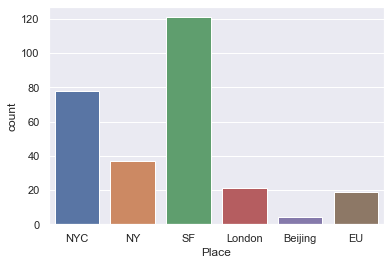

```python
sns.countplot(df_new['Place'])
```